# Tanzania population water point accessibility

The final output creates a regular grid of 1km cells, with each cell containing attributes on:

- Time to water point
- Population estimates
- Land cover

The analysis is run twice, once considering all water points and in the second instance just considering functional waterpoints.

## Data downloads

This analysis is divided between R and PostGIS.

## The code in R:

**Water points and accessibility**

- Load water points and filter them, removing NAs and those outside Tanzania
- Take friction data which is a measure of how hard it is to cross a 1km cell. From this we calculate travel times to nearest waterpoint.

**Landcover**

- The individual landcover tiles are loaded and mosaicked into a single continuous raster dataset.

## PostGIS

The following data is loaded into PostGIS

- World pop population data at 100m grid cells for 2020
- Travel times to nearest water point (1km raster)
- 2020 landcover data (1km raster)

In PostGIS the following pre-processing and analysis is conducted

**Pre-processing**

- The accessibility raster (1km) is converted to polygons
- The world pop data (100m) is converted to centroids

**Analysis**

- The world pop centroids are joined to the accessibility polygons with the population in each 1km cell being summed giving accessibility and population per 1km polygon.
- The accessibility and population per 1km polygon is converted to centroids, which are used to extract a land cover value

**Outputs**

- Accessibility and population per 1km polygon are then spatially joined with the land cover centroids to produce a final 1km polygon cell layer with accessibility, population and landcover.

## R analysis

```r
knitr::opts_chunk$set(warning = FALSE, message = FALSE)
```

## libraries

```r
library(sf)
library(terra)
library(raster)
library(tidyverse)
library(gdistance)
library(tmap)
library(stars)
```

# Loading/pre-processing

## Country

Load Tanzania country outline, this will be used to remove water points that fall outside of the country boundary.

```r
Tanzania_shape <- st_read("Input_data/gadm41_TZA_shp/gadm41_TZA_0.shp")%>%
  st_transform(., 21035)
```

## Water points

Load water points, remove NA values, project to local coordinate reference system and the plot to check

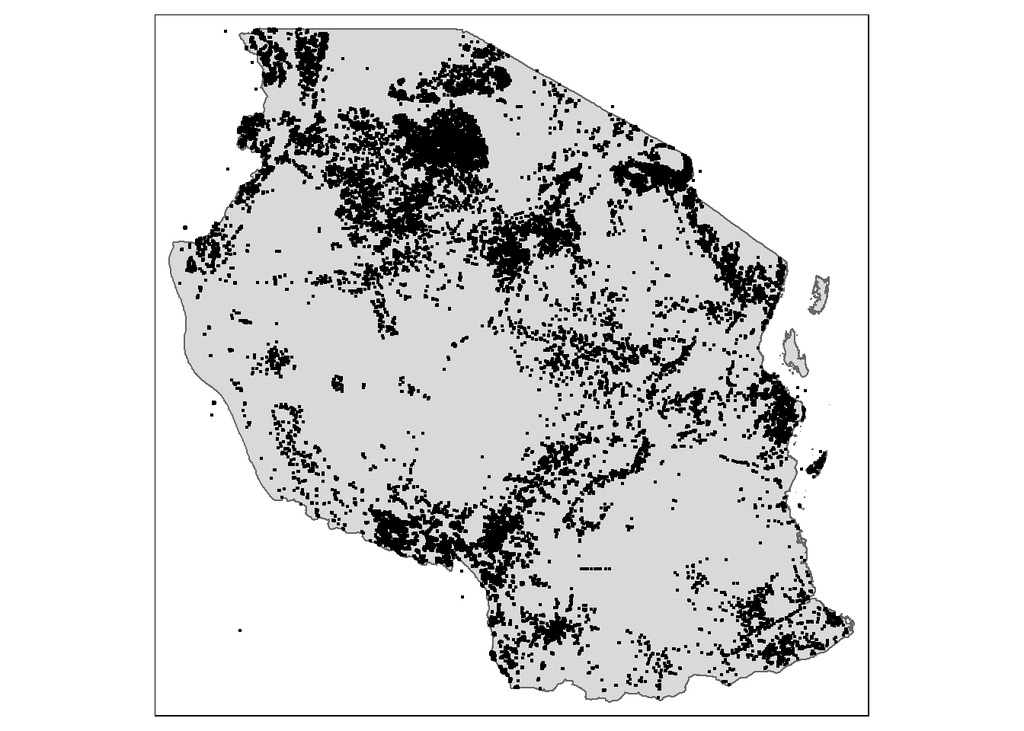

```r
wp_data <- read_csv("Input_data/CDMT_WP/CDMT_WPs_2019.csv", locale = locale(encoding = "latin1"),
na = "n/a")%>%
  filter(!is.na(LONGITUDE))%>%
  filter(!is.na(LATITUDE))%>%
  st_as_sf(., coords = c("LONGITUDE", "LATITUDE"),  crs = 4326)%>%
  st_transform(., 21035)%>%
  # comment this out if all points are required, this is just functional points
  filter(DPSTATUS=="Functional")


#plot to check read in correctly
tm1 <- tm_shape(Tanzania_shape)+
  tm_polygons()+
  tm_shape(wp_data) +
  tm_dots()

#plot
tm1
```

Remove water points that our outside of the country boundary, plot to check

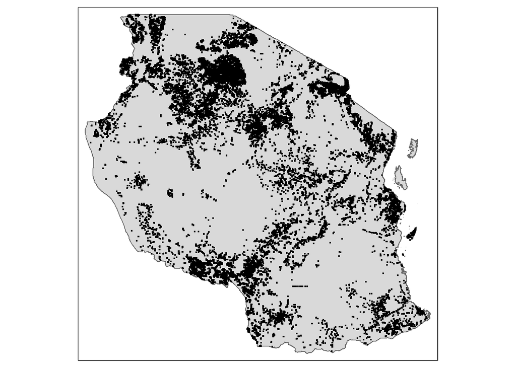

```r
points_in_tanzania <- wp_data[Tanzania_shape,]

tm2 <- tm_shape(Tanzania_shape)+
  tm_polygons() +
  tm_shape(points_in_tanzania) +
  tm_dots()

#plot
tm2
```

## Friction surface

Read in the friction surface, transform to local coordinate reference system and plot to check.

See this article for more info: https://medium.com/@abertozz/mapping-travel-times-with-malariaatlas-and-friction-surfaces-f4960f584f08. Also see: https://t1nak.github.io/blog/2020/cost/

```r
#creating function for transforming stars to raster

Tz_friction <- terra::rast("Input_data/Malaria_atlas/2020_walking_only_friction_surface_TZA.tiff")%>%
  terra::project(., "EPSG:21035")%>%
  raster()

#plot to check
#plot(Tz_friction)
```

Work out transition costs, we use Queen’s case contiguity - this means that we only work out the cost from a central pixel to the neighbours (queen’s case). See: https://gis.stackexchange.com/questions/355321/transition-function-inputs

Note there was an error with the pacakge gdistance and the latest version of R. To resolve this you must install older package version with latest version of R - https://github.com/AgrDataSci/gdistance/issues/15

The raster plotted here is travel time to most accessible water point.

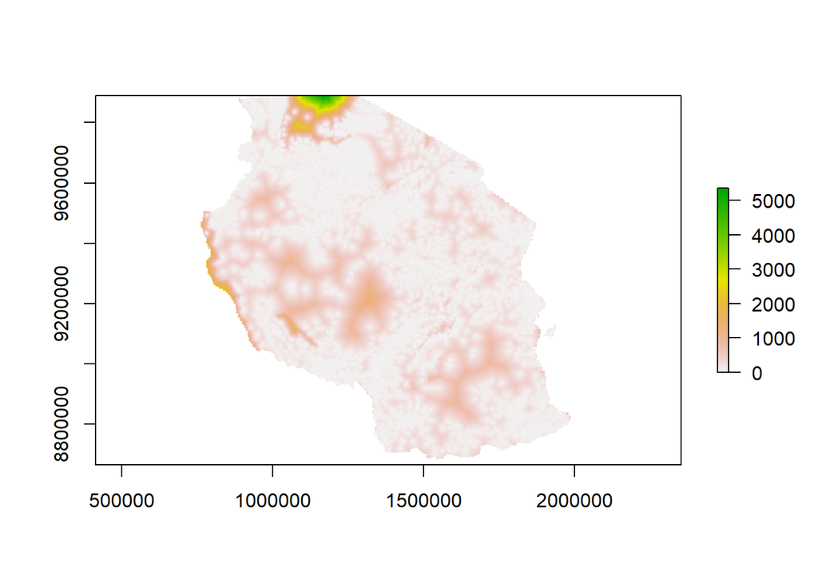

```r
cost <- gdistance::transition(Tz_friction, function(x) 1/mean(x), 8)
cost_correct <- gdistance::geoCorrection(cost)

wp_points_as_matrix <- points_in_tanzania%>%
  st_coordinates(.)

access_raster <- gdistance::accCost(cost_correct, wp_points_as_matrix)

#change the output file name to either all water points or func for just functional water points
raster::writeRaster(access_raster, "Output_data/func_wp_access_CDMT.TIFF", overwrite=TRUE)

# minutes of travel to a water point
plot(access_raster)
```

## Global Human Settlement Layer (GHSL) landcover

```r
#creating function for transforming stars to raster

library(terra)
R10_C21 <- terra::rast("Input_data/GHSL/Rasters/GHS_SMOD_E2020_GLOBE_R2022A_54009_1000_V1_0_R10_C21.tif")


R10_C22 <- terra::rast("Input_data/GHSL/Rasters/GHS_SMOD_E2020_GLOBE_R2022A_54009_1000_V1_0_R10_C22.tif")
R10_C23 <- terra::rast("Input_data/GHSL/Rasters/GHS_SMOD_E2020_GLOBE_R2022A_54009_1000_V1_0_R10_C23.tif")
R11_C22 <- terra::rast("Input_data/GHSL/Rasters/GHS_SMOD_E2020_GLOBE_R2022A_54009_1000_V1_0_R11_C22.tif")
R11_C23 <- terra::rast("Input_data/GHSL/Rasters/GHS_SMOD_E2020_GLOBE_R2022A_54009_1000_V1_0_R11_C23.tif")

merge<-terra::mosaic(R10_C21, R10_C22, R10_C23, R11_C22, R11_C23)%>%
   terra::project(., "EPSG:21035", method="near")

raster::writeRaster(merge, "Output_data/GHSL_merge.tif", overwrite=TRUE)
```

## Load rasters to PostGIS

To load rasters into PostGIS, go to `C:\Program Files\PostgreSQL\15\bin`, highlight raster2pgsql then in the window explorer bar (file path bar) type cmd. Run the following, changing the file paths.

```r
# Worldpop

raster2pgsql.exe -s 4326 -N -32767 -t 100x100 -I -C -M -d C:\Users\Andy\Downloads\tza_ppp_2020_UNadj_constrained.tif  rasters_pop > C:\Users\Andy\Downloads\world_pop_2020.sql

raster2pgsql.exe -s 4326 -N -32767 -t 100x100 -I -C -M -d C:\Users\Andy\Downloads\tza_ppp_2020_UNadj_constrained.tif public.world_pop_2020 | psql -U postgres -d Tanzania_data -h localhost -p 5432

# accessibility raster, either using functional (func) or all water points

raster2pgsql.exe -s 21035 -N -32767 -t 100x100 -I -C -M -d C:\Users\Andy\Downloads\func_wp_access_CDMT.TIFF  access_raster > C:\Users\Andy\Downloads\func_access_raster.sql

raster2pgsql.exe -s 21035 -N -32767 -t 100x100 -I -C -M -d C:\Users\Andy\Downloads\func_wp_access_CDMT.TIFF public.func_access_raster | psql -U postgres -d Tanzania_data -h localhost -p 5432

# landcover

raster2pgsql.exe -s 21035 -N -32767 -t 100x100 -I -C -M -d C:\Users\Andy\Downloads\GHSL_merge.tif  rasters_landcover > C:\Users\Andy\Downloads\rasters_landcover.sql

raster2pgsql.exe -s 21035 -N -32767 -t 100x100 -I -C -M -d C:\Users\Andy\Downloads\GHSL_merge.tif public.landcover | psql -U postgres -d Tanzania_data -h localhost -p 5432
```